# Dynamic reporting with R and Quarto: reanalyzing the Titanic dataset

Statistical report

Author

Simon Schwab

Published

November 21, 2025

Abstract

An introduction to Quarto for participants in the Good Research Practice (GRP) course at the University of Zurich.

## Objectives

We will learn Quarto by a practical example: a reanalysis of the Titanic data. Quarto enables you to put together content, executable code, tables, and figures into a finished document. To learn more about Quarto, see https://quarto.org.

We will focus on Quarto Documents, but you can also create other Quarto projects:

- Presentations
- Dashboards
- Websites
- Books
- Manuscripts

### Structure of this document

In the analysis below, I stick to the following structure. This structure can also be seen in the table of contents on the right.

```
flowchart TB
O("Objectives") --> D("Data import")
D --> P("Data processing")
P --> Q("Quality control")
Q --> DS("Descriptive statistics")
DS --> PA("Primary analysis")
PA --> C("Computing information")
```

Quarto supports flowcharts using Mermaid. For more details, see [Diagrams with Quarto](https://quarto.org/docs/authoring/diagrams.html).

Here is a somewhat more detailed [Data Analysis Workflow](https://swisstransplant.github.io/rcookbook/#data-analysis-workflow) that I’m using in my own projects.

A final word of caution.

> A $100 analysis can make a $1,000,000 study worthless –Frank Harrell

### Objective of our data analysis

To identify variables associated with passenger survival in the 1912 Titanic incidence.

## Data import

Usually this step involves reading an Excel file, data cleaning, merging different data sets, reshaping data, etc. Here, it is very simple. We load the data from the package `carData`. We also do quality control with the package `testit`.

If you don’t have the required packages already installed, you first need to install them.

```r
install.packages("carData")
install.packages("testit")
```

```r
library(carData)
library(testit)
```

After loading the package, you can find the data in the object `TitanicSurvival`; I will rename it to `data` for simplicity. I show data for some randomly selected passengers in the table below.

```r
data = TitanicSurvival

set.seed(2024)
idx = sample(nrow(data), 6)
data[idx,]
```

|  | survived | sex | age | passengerClass |
| --- | --- | --- | --- | --- |
| Richards, Master. George Sibley | yes | male | 0.8333 | 2nd |
| Cacic, Mr. Luka | no | male | 38.0000 | 3rd |
| Vendel, Mr. Olof Edvin | no | male | 20.0000 | 3rd |
| Karaic, Mr. Milan | no | male | 30.0000 | 3rd |
| Andersen, Mr. Albert Karvin | no | male | 32.0000 | 3rd |
| Eustis, Miss. Elizabeth Mussey | yes | female | 54.0000 | 1st |

**NoteExercise 1**

Inspect the data, what variables are available and what type of data is it (continuous, binary, categorical, etc.)?

## Data processing

This data set is very tidy and clean. We don’t need to do a lot of processing.

### Histogram of age

However, it is important to get an overview of the data. I need to understand what the data looks like, for example, by plotting histograms for all continuous variables. In our data, only age is continuous.

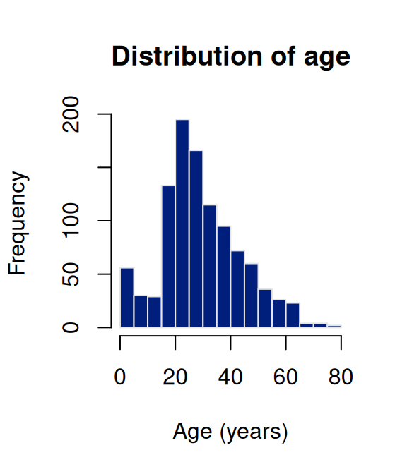

```r
hist(data$age, main = "Distribution of age", xlab = "Age (years)",
     col = "#001E7C", border = "grey90")
```

**NoteExercise 2**

Replace the label “Frequency” with “Counts”.

### Definition of outcome

Next, I define the primary outcome with a new variable called `event`. It is a binary outcome set to `TRUE` when the passenger survived and `FALSE` otherwise.

```r
data$event = data$survived == "yes"
```

### Missing data

A very important step is to assess and address missing data; `age` has missing data. Thus, I report the number of missing values in age (%).

```r
count = sum(is.na(data$age))
prc = sum(is.na(data$age))/nrow(data)*100

tab = data.frame(age = sprintf("%d (%.1f%%)", count, prc))
tab
```

| age |
| --- |
| 263 (20.1%) |

**NoteExercise 3**

What are the implications of these missing data on the interpretation of our results?

### Create analysis dataset

We will do a complete case analysis. Actually, this is not really recommended; however, in this tutorial, it is fit for purpose. The analysis data set is stored in the object `titanic`.

```r
idx = complete.cases(data)
titanic = data[idx,]
```

**NoteExercise 4**

How can missing data be addressed otherwise?

## Quality control

Quality control is a crucial step and should be part of any data analysis pipeline. A test is like a question to the data that should be true, for example:

- Do all passengers have a value in `passengerClass` (no missing)?
- Are all the values in `age` larger than 0 and smaller than 100?

As soon as the logical expression within the function `assert` is not met, an error will be thrown.

```r
assert(!is.na(titanic$passengerClass))
```

**NoteExercise 5**

You can now extend the code block above. You could test the variable `sex` for completeness. You can try to test that the age range is between 0 and 100, for example.

> You can test *anything*. Start by testing the obvious.

## Descriptive statistics

I report some descriptives for sample size, age, and sex.

```r
q_age = quantile(titanic$age, probs = c(0.5, 0.25, 0.75))

tab = data.frame(

  Descriptives = c(
    sprintf("N=%d", nrow(titanic)),
    sprintf("%0.f (%0.f--%0.f)", q_age[1], q_age[2], q_age[3]),
    sprintf("%d (%0.f)", sum(titanic$sex == "female"),
            sum(titanic$sex == "female")/nrow(titanic)*100), # calculate %
    sprintf("%d (%0.f)", sum(titanic$sex == "male"),
            sum(titanic$sex == "male")/nrow(titanic)*100) # calculate %
  )
)

rownames(tab) = c("Sample Size",
                  "Age in years, median (IQR)",
                  "Sex: female (%)", "Sex: male (%)")
tab
```

Table 1: Descriptives of the Titanic passengers.

|  | Descriptives |
| --- | --- |
| Sample Size | N=1046 |
| Age in years, median (IQR) | 28 (21–39) |
| Sex: female (%) | 388 (37) |
| Sex: male (%) | 658 (63) |

**NoteExercise 6**

You can now try to extend Table 1 and also report the number of passengers (and %) per `passengerClass`.

## Primary analysis

I fit a logistic regression model to predict survival indicated in the variable `event`. The reference levels compare females to males and 1st/2nd class to 3rd class.

The model defaults to using the first factor level as the reference, but this can be changed.

```r
titanic$sex = factor(titanic$sex, levels = c("male", "female"))
titanic$passengerClass = factor(titanic$passengerClass, levels = c("3rd", "2nd", "1st"))

fit = glm(event ~ sex + age + passengerClass, data = titanic,  family = binomial)

tab = summary(fit)$coefficients
as.data.frame.matrix(tab)
```

|  | Estimate | Std. Error | z value | Pr(>\|z\|) |
| --- | --- | --- | --- | --- |
| (Intercept) | -1.2654312 | 0.2028675 | -6.237722 | 0e+00 |
| sexfemale | 2.4978447 | 0.1660365 | 15.043949 | 0e+00 |
| age | -0.0343932 | 0.0063310 | -5.432511 | 1e-07 |
| passengerClass2nd | 1.0090908 | 0.1983625 | 5.087104 | 4e-07 |
| passengerClass1st | 2.2896606 | 0.2258019 | 10.140129 | 0e+00 |

This table is not looking nice and is also hard to interpret. Therefore, I improve this table; see Table 2. That is how I like to report a logistic model in a paper.

**NoteExercise 7**

Run each line in the code block below one by one, and take time to understand what each step does.

```r
tab             = as.data.frame.matrix(tab)
# change beta to odds ratio
tab$OR          = as.character(signif(exp(tab$Estimate), digits = 3))
tab$z.value.fmt = as.character(signif(tab$`z value`, digits = 3))
tab$pvalue      = ggsurvfit::format_p(tab$`Pr(>|z|)`)

# add 95% confidence interval
ci = confint(fit, level = 0.95)
lower = as.character(signif(exp(ci[,1]), digits = 2))
upper = as.character(signif(exp(ci[,2]), digits = 2))

tab$CI = sprintf("from %s to %s", lower, upper)

tab.tidy = tab[, c("OR", "CI", "z.value.fmt", "pvalue")]
colnames(tab.tidy) = c("Odds ratio", "95% CI", "z value", "p value")
tab.tidy
```

Table 2: Results from a logistic regression model.

|  | Odds ratio | 95% CI | z value | p value |
| --- | --- | --- | --- | --- |
| (Intercept) | 0.282 | from 0.19 to 0.42 | -6.24 | <0.001 |
| sexfemale | 12.2 | from 8.8 to 17 | 15 | <0.001 |
| age | 0.966 | from 0.95 to 0.98 | -5.43 | <0.001 |
| passengerClass2nd | 2.74 | from 1.9 to 4.1 | 5.09 | <0.001 |
| passengerClass1st | 9.87 | from 6.4 to 15 | 10.1 | <0.001 |

The row names could be improved, but I think we are done.

We found that on the Titanic, females, younger passengers, and those in 1st or 2nd class had a higher chance of survival.

Any suggestion to improve this analysis? Also, if you have seen any error, typo, or any other mishap in this document, please let me know. I try to improve it every year.

The lastest version of this document can be found at https://github.com/schw4b/titanic.